# Contract Factor Forecasting

ETC5543 - SEC Internship

21/10/2026

# Background

What the contract factor is, how the current TWAP-based model forecasts it and where it falls short, and our end-to-end workflow.

## What is Contract Factor?

**What is Contract Factor and why is it important?**

- Wind and solar farms do not generate evenly, and the market price changes every 5 minute so the average price a farm earns is not the same as the average market price.
- Contract Factor (CF) compares the two: the higher the CF, the more the farm earns per MWh compared with the market average. The price a farm earns is measured the way SEC’s VRET contracts pay: never below $0, so negative prices count as $0.
- SEC uses CF to forecast the revenue of its VRET wind and solar assets in the Corporate Model.

**How Analytics defines and calculates CF for VRET wind and solar assets**

$$\text{AssetDWAP} = \frac{\sum \big(\text{AssetOutput [MWh]} \times \max(\text{VIC1Price}, 0)\ [\$/\text{MWh}]\big)}{\sum \text{AssetOutput [MWh]}}$$

$$\text{AssetCF} = \frac{\text{AssetDWAP}}{\text{AssetTWAP}}$$

- DWAP: average price weighted by the asset’s output, negative prices floored at $0
- TWAP: average market price over the period
- CF is calculated for each month from 30-minute data.

We use monthly CF throughout, because SEC calculates CF monthly, our price, LGC and weather inputs are monthly, and daily or weekly CF is much noisier.

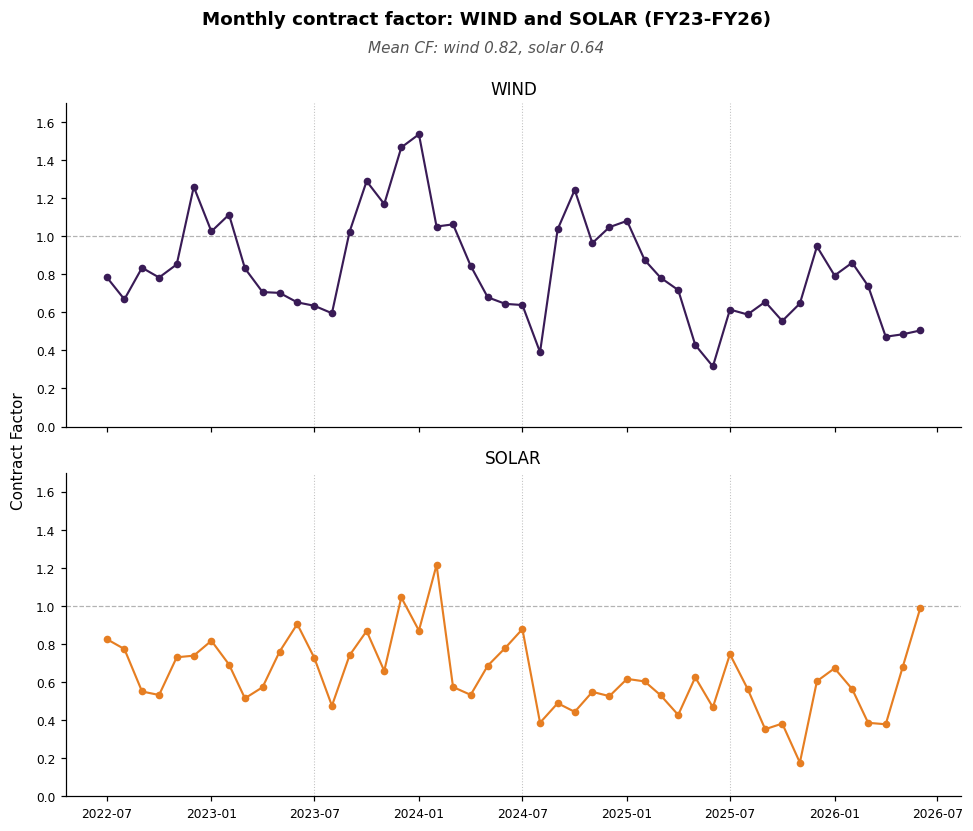

## The recent CF forecasting model

Exponential relationships fit between VIC1Price TWAP and CF, separately for each season

**Our approach: This project extends the current model in two ways.**

- **Weather:** Capture performance depends on whether generation happens in the hours when prices are good. The current model has no information about when generation happens, so we introduce weather variables (irradiance, wind speed, temperature, humidity) as explanatory features.
- **Certificate price (LGC):** Historical negative prices were shaped by a certificate worth up to $66. It is worth about $8 today and the scheme ends in 2030, so the price structure has to be corrected before it can be used to forecast forward.

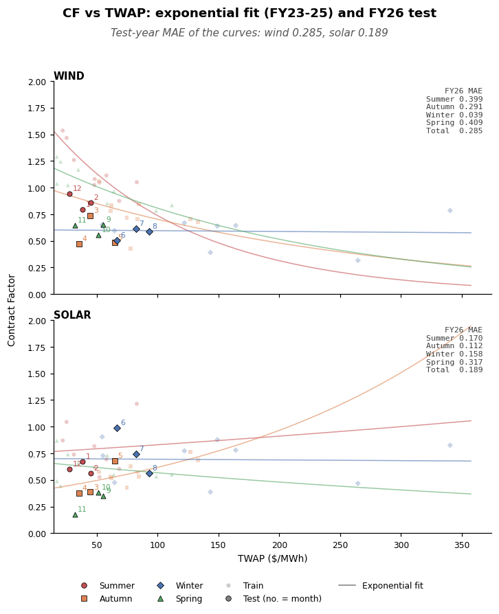

## End-to-End Modelling Workflow

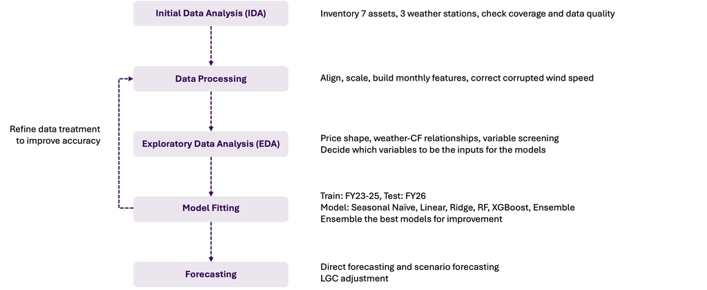

# Data

The seven VRET assets and three weather stations we use, and the candidate variables for the wind CF model.

## Assets & Stations

Type

ID

Location

Notes

Wind asset

DUNDWF3

Dundonnell

Very clean history: only four 1-day exclusions.

BRYB1WF1

Berrybank

Six short exclusions (longest 12 days).

BULGANA1

Bulgana

Co-located battery (20 MW). Longest exclusion: Jun 2024 – Dec 2025 (578 days), plus other short ones.

MRTLSWF1

Mortlake

Not yet online before Jun 2023, so no usable data in FY23.

Solar asset

WINTSF1

Winton

Two exclusions: Jul – Aug 2024 (61 days) and Nov 2024 – Jan 2025 (53 days).

GLENSF1

Glenrowan

Started operating late: data begins 1 Dec 2023

COHUNSF1

Cohuna

Many long exclusions, including Mar 2024 – Apr 2025 (376 days).

Weather Station

89002

Ballarat Aerodrome

- **Wind:** 89002 and 86338 are averaged because their wind speed correlates with generation (r = 0.32 - 0.47). **85280 is excluded** because it is weak (r = 0.06 - 0.20).

- **Solar:** all 3 stations are averaged because GHI correlations are almost identical (differences ≤ 0.02 for each asset), data quality checked.

86338

Melbourne (Olympic Park)

85280

Latrobe Valley Airport

We model CF at portfolio level (wind and solar), not asset by asset

## Variables - WIND CF Model

| Variable |  | What it is | Why consider it |
| --- | --- | --- | --- |
| VIC1 Price | twap | Monthly mean of half-hourly VIC1 price (1) | TWAP is the CF denominator, and the current method uses it |
|  | twap_neg | Mean price of the half-hours below $0 | DWAP floors negatives at $0 but TWAP does not, so deeper negatives raise CF |
|  | twap_pos | Mean price of the half-hours at or above $0 | Sets the level of the positive prices that make up DWAP |
| Weather | wind_speed_kph | Monthly mean wind speed | Main driver of wind output **(calibrated)** |
|  | temp_c | Monthly mean temperature | Related to air density and the seasonal cycle |
|  | rh | Relative humidity | Humid air is less dense, so wind carries slightly less power at the same wind speed |
|  | dp_c | Dew point | Direct measure of air moisture (unlike RH, it does not change with temperature). |
|  | rainfall_mm | Monthly rainfall | Rainy weather systems such as fronts and storms are often windy. |
| Seasonality | month_sin, month_cos | Month of the year as a circle (seasonal shape) | Captures the seasonal pattern of prices and generation |

(1) Monthly mean TWAP includes both positives and negatives

# Feature selection

Which variables enter the wind model, chosen from their correlation with CF and checked for multicollinearity.

## Feature selection - WIND Model

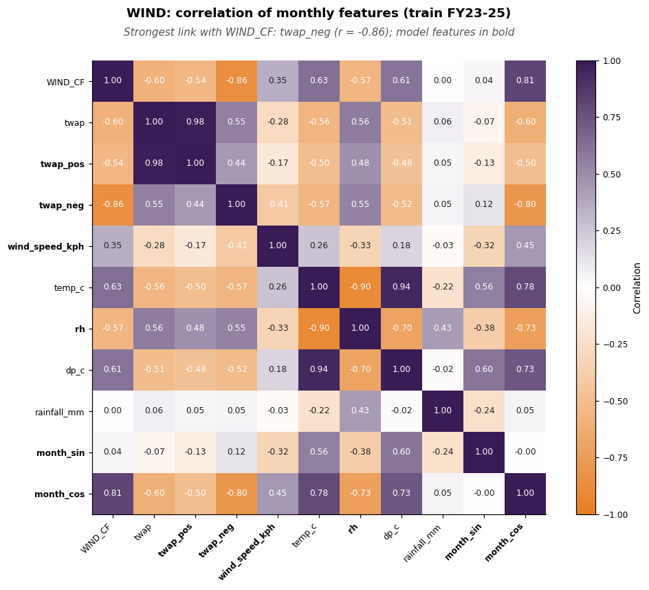

# Price structure & LGC

Why negative prices raise CF, and how replayed historical prices are adjusted for a cheaper certificate (LGC).

## Negative prices and the certificate that sets their floor

- FY26: **26%** of half-hours below $0, up from **20%** in FY23, and **56%** of them sit in the shallow −$10 to $0 band
- Why: **Supply and demand decide when prices go negative. The certificate decides how deep.**
- LGC = one certificate per MWh of renewable generation; retailers are legally required to buy them; scheme ends 31 Dec 2030
- LGC fell from ~$32 (FY25 avg) to ~$6 by Jun 2026 (**−82%**), so the floor has lifted toward zero and negative prices are getting shallower

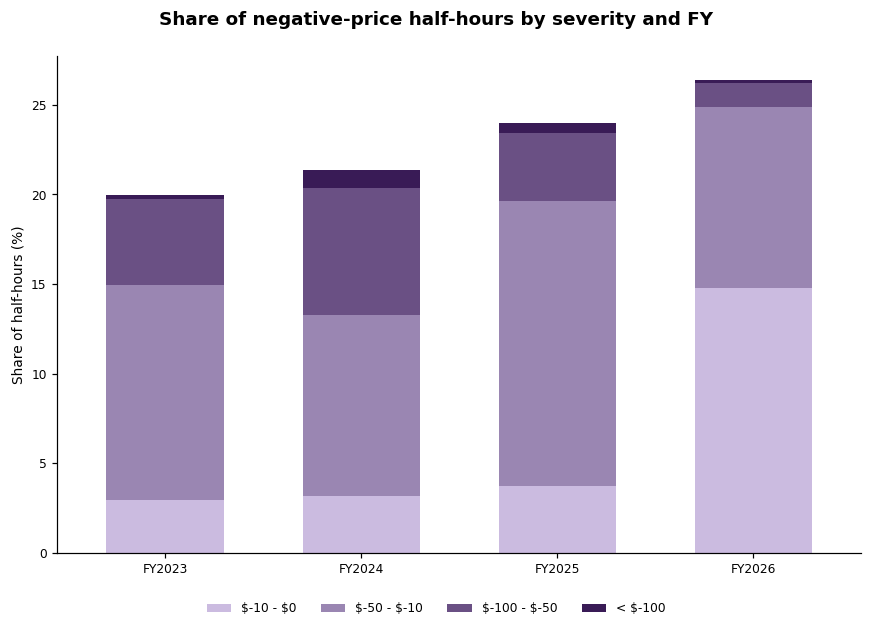

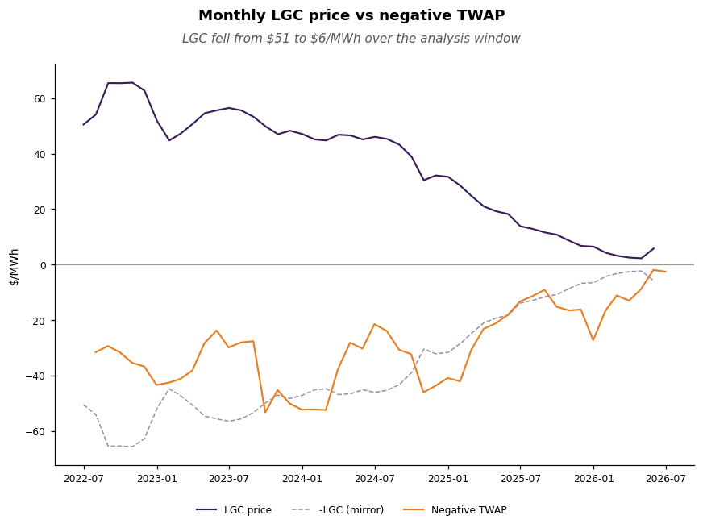

## Adjusting replayed prices for a cheaper certificate

**The problem:** Our long-horizon forecast reuses the monthly price structure (negative TWAP, positive TWAP, negative share) of past years. FY23–24 had a certificate around $50, so their negative prices were far deeper than FY27–29 will see (LGC ~$8). Replaying that structure unchanged overstates the zero-dollar-floor benefit in CF.

**Step 1: Shrink the negative half-hours**

$$P'_t = \begin{cases} s \cdot P_t & P_t < 0 \\ P_t & P_t \ge 0 \end{cases} \qquad s = \frac{a + b\,\text{LGC}_{\text{target}}}{a + b\,\text{LGC}_{\text{hist}}}, \qquad s \in [0, 1]$$

depth = how deep a month’s negatives go = −(5th percentile of price)  
*s* = predicted depth at the target LGC / predicted depth at the historical LGC  
*a* = depth that exists with no certificate at all (averaged over the year)  
*b* = extra dollars of depth per dollar of certificate

**Step 2: Rescale the positive half-hours so the month still matches the forecasted price**

$$P''_t = \begin{cases} P'_t & P_t < 0 \\ k \cdot P'_t & P_t \ge 0 \end{cases} \qquad k = \frac{\text{TWAP}_{\text{target}} - n_s\,\bar{P}'_{\text{neg}}}{(1 - n_s)\,\bar{P}_{\text{pos}}}$$

Note that:

$$\text{TWAP} = n_s\,\bar{P}_{\text{neg}} + (1 - n_s)\,\bar{P}_{\text{pos}}$$

**Example:** replaying January 2023 into January 2028

|  | Historical | After adjustment |
| --- | --- | --- |
| LGC | **$52** | **$8** (forecast) |
| Negative half-hours (27% of month) | avg **-$42.55** | avg **-$21.68** (s = 0.51) |
| Positive half-hours | avg **$80.96** | avg **$102.03** (k = 1.26) |
| Monthly TWAP | $48.09 | **$69.11** ( = monthly forecasted price) |

# Modelling & forecasting

How the FY27-29 scenario forecast is built, and the baselines and models we compare.

## Forecasting Method

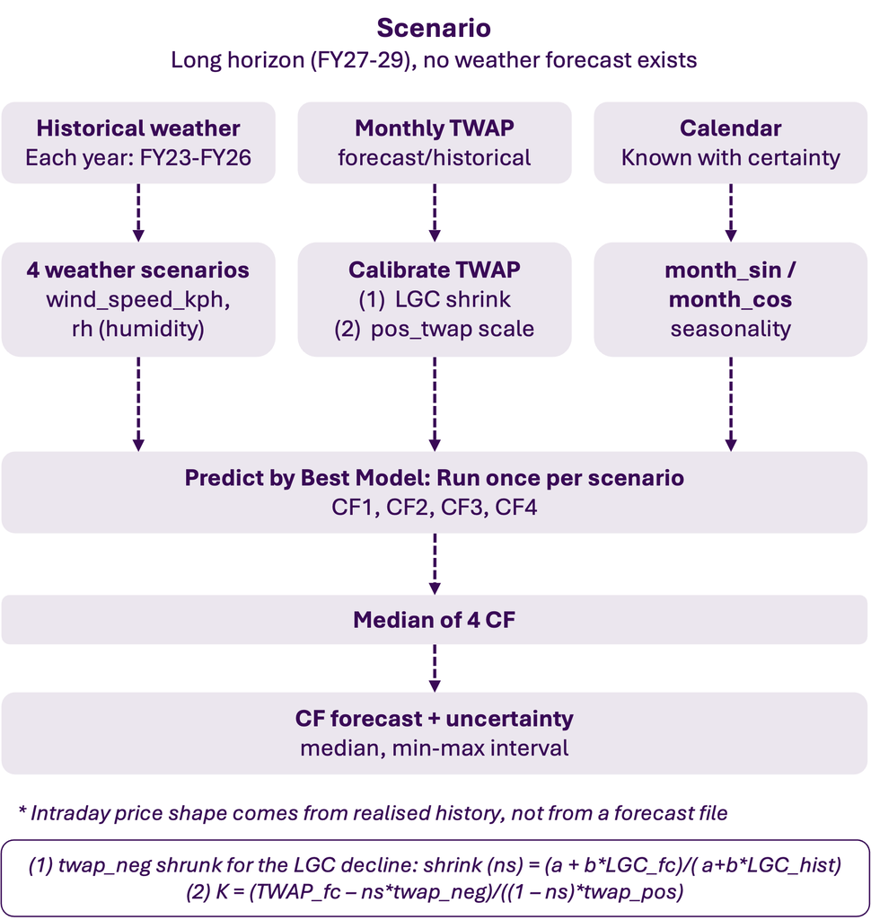

## Model Summary

[output not shown]

# Results

Every model tested on FY26 against the actual CF, and a closer look at the best wind models.

## WIND CF Overview

Training set: FY23-25, Test set: FY26. Model comparison using MAE

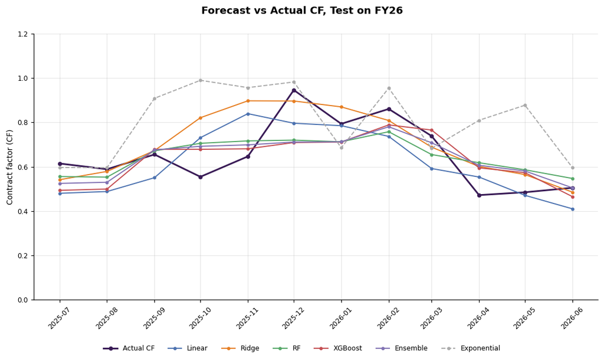

| Benchmark | MAE |
| --- | --- |
| Seasonal Naive | 0.212 |
| Exponential | 0.178 |
| Model | MAE |
| Ensemble | **0.085** |
| XGBoost | 0.088 |
| Ridge | 0.090 |
| RF | 0.093 |
| Linear | 0.111 |

- Ensemble, XGBoost and Ridge are the most accurate (MAE 0.085-0.090), and the gap between them is small
- All models beat both baselines but miss the October trough. Ridge reaches the December peak but over-predicts October-November.
- Choose best 3 models

## WIND CF Best models

Feature importance

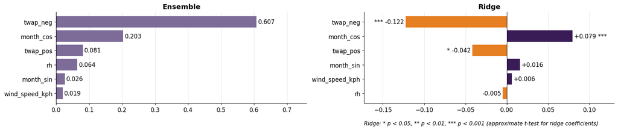

Test FY26

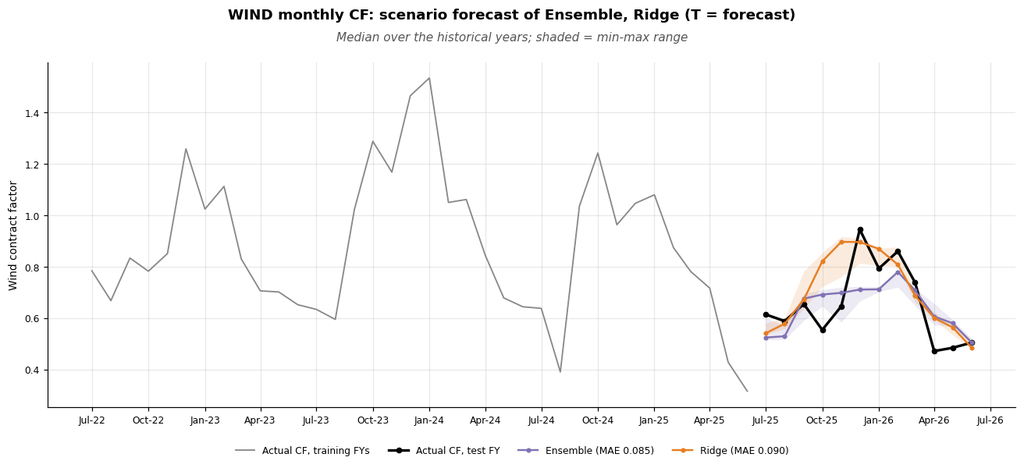

**Key takeaway:**

- Both models rely mostly on twap_neg and month_cos: deeper negative prices and summer months give a higher CF
- Weather inputs contribute much less than price
- Both models track the seasonal cycle of actual CF but miss month-specific swings.

# Conclusion

# Appendix

Calibration of the corrupted wind speed data, the solar CF model, and feature imporance and the FY27-29 forecast of every model.

## Abbreviations

| Abbreviation | Meaning | Abbreviation | Meaning |
| --- | --- | --- | --- |
| CF | Contract factor = DWAP / TWAP | MAE | Mean absolute error |
| DWAP | Generation-weighted average price, negative prices floored at $0 | RMSE | Root mean squared error |
| TWAP | Time-weighted average price (monthly mean of the half-hourly price) | MAPE | Mean absolute percentage error |
| VIC1 | Victorian price region of the NEM | R² | Coefficient of determination |
| NEM | National Electricity Market | VIF | Variance inflation factor |
| VRET | Victorian Renewable Energy Target | RF | Random forest |
| SEC | State Electricity Commission of Victoria | XGBoost | Extreme gradient boosting |
| LGC | Large-scale Generation Certificate | QM | Quantile mapping |
| MLF | Marginal loss factor | GHI | Global horizontal irradiance |
| DUID | AEMO identifier of a generating unit | DNI | Direct normal irradiance |
| FY | Financial year, July to June (FY26 = Jul 2025 - Jun 2026) | IDA | Initial data analysis |
| HH | Half-hour (the 30-minute interval of the price and generation data) | EDA | Exploratory data analysis |
| ASX | Australian Securities Exchange (adjusted monthly price forecast) | AEMO | Australian Energy Market Operator |

## Data sources

| Data | File (data/raw/) | Source | Used for |
| --- | --- | --- | --- |
| Generation of each asset and VIC1 price, half-hourly | GenerationMW_FY19-26.csv | NEMSight (AEMO data) | Contract factor, price features |
| Asset list, capacity and contracted share | Asset.csv | SEC | Scaling and portfolios |
| Exclusion periods | ExclusionPeriods.csv | SEC | Removing excluded half-hours |
| Marginal loss factors | MLF_FY23-26.csv | AEMO | Scaling the generation |
| Weather (wind speed, temperature, humidity, ...), half-hourly | HistoricWeather_30min.csv | DTN | Wind features |
| Solar irradiance (GHI, DNI, air temperature), half-hourly | HistoricSolarIrradiance_30min.csv | Solcast | Solar features |
| Historical LGC price | HistoricLGCPrice.csv | SEC | LGC adjustment of negative prices |
| Forecast LGC price by calendar year | ForecastedLGCPrice.csv | Mercari | LGC adjustment of FY27-29 |
| Price forecast, half-hourly | PriceForecast_30min.csv | SEC | Forecast TWAP T of the FY26 test |
| ASX-adjusted monthly price forecast | PriceForecast_Month.csv | SEC | Forecast TWAP T of FY27-29 |
| Coordinates of the weather stations and farms | Locations.csv | BoM station list, asset locations | Choice of weather stations |

## Exclusion periods

- **Exclusion periods** (`ExclusionPeriods.csv`, SEC) are the days an asset’s output does not count under its contract, for example outages or commissioning. Their half-hours are set to missing before the CF is computed, so a monthly CF uses only the available half-hours.
- The longest are BULGANA1 (Jun 2024 - Dec 2025, 578 days) and COHUNSF1 (Mar 2024 - Apr 2025, 376 days); MRTLSWF1 and GLENSF1 came online during the window (light grey).

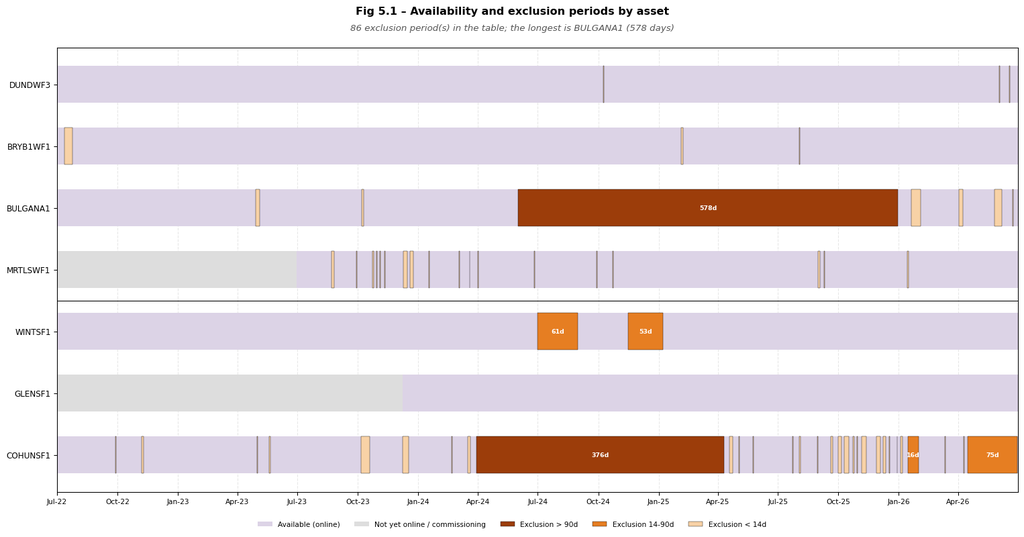

## Calibrate data: Wind_speed_kph

- DTN wind speed data for stations 89002 & 86338 suffered systematic amplitude compression from 7/10/2025 – 14/4/2026 (6 months, 9,120 half-hours)
- Critically, **temporal rank order is preserved**: Spearman correlation with actual generation barely changed (89002: 0.488 → 0.475; 86338: 0.337 → 0.356). This means the signal is recoverable.

**⇒ Correction method - Quantile Mapping (QM):** a standard technique in meteorology for bias-correcting climate data. Each corrupted value is mapped to the same percentile in the clean historical distribution, stratified by (month x half-hour of day) to respect seasonal and diurnal wind patterns. Reference period: Oct-Apr of FY23-25 (3 clean years)

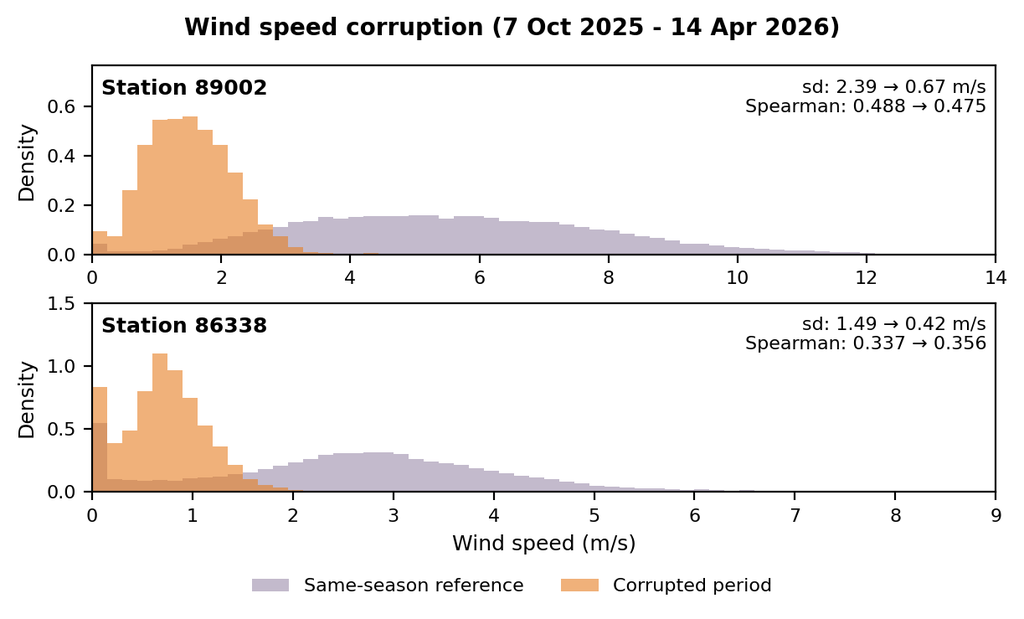

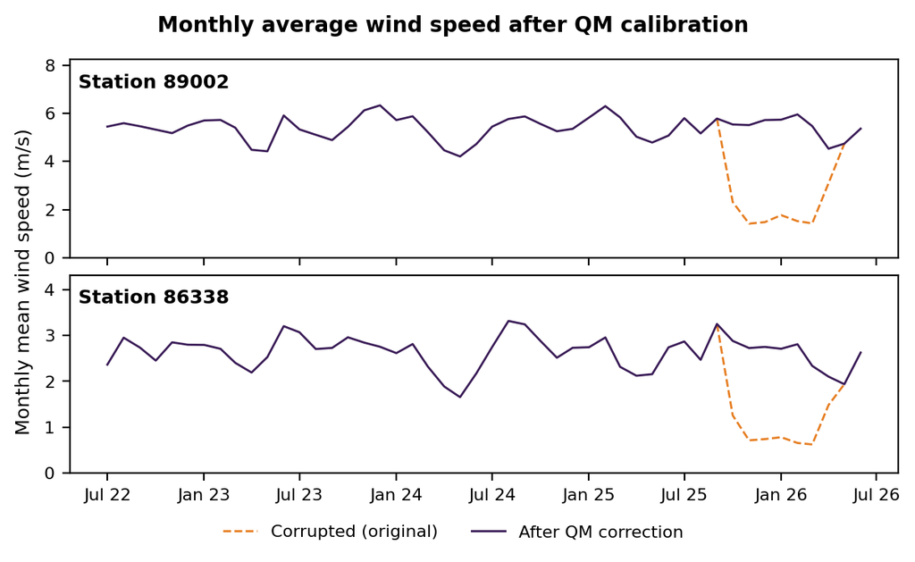

## Variables - SOLAR CF Model

| Variable |  | What it is | Why consider it |
| --- | --- | --- | --- |
| VIC1 Price | twap | Monthly mean of half-hourly VIC1 price, including negatives | TWAP is the CF denominator, and the current method uses it |
|  | twap_neg | Mean price of the half-hours below $0 | DWAP floors negatives at $0 but TWAP does not, so deeper negatives raise CF |
|  | twap_pos | Mean price of the half-hours at or above $0 | Sets the level of the positive prices that make up DWAP |
| Weather | ghi | Global horizontal irradiance | Main driver of solar output |
|  | dni | Direct normal irradiance (direct beam) | Separates clear days from cloudy days |
|  | air_temp_c | Air temperature | Panel efficiency falls when it is hot |
| Seasonality | month_sin, month_cos | Month of the year as a circle | Captures the seasonal pattern of prices and generation |

## Feature selection - SOLAR Model

- For Solar, only twap_neg is clearly linked to SOLAR_CF (r −0.40); the weather variables are weakly correlated (|r| ≤ 0.11), so the price structure drives solar CF more than the sunshine itself.
- We kept ghi as the physical driver and dropped redundant variables: dni (r 0.91 with ghi), air_temp_c (r 0.89 with ghi; tested and did not lower the forecast error) and twap (r 0.98 with twap_pos).
- VIF flags ghi and month_cos (VIF ≈ 22, r 0.95): both follow the seasons. We keep both, because RF, the model used for the forecast, is not affected by correlated inputs, and Ridge shrinks them.
- **Solar features: ghi, twap_neg, twap_pos, month_sin, month_cos**

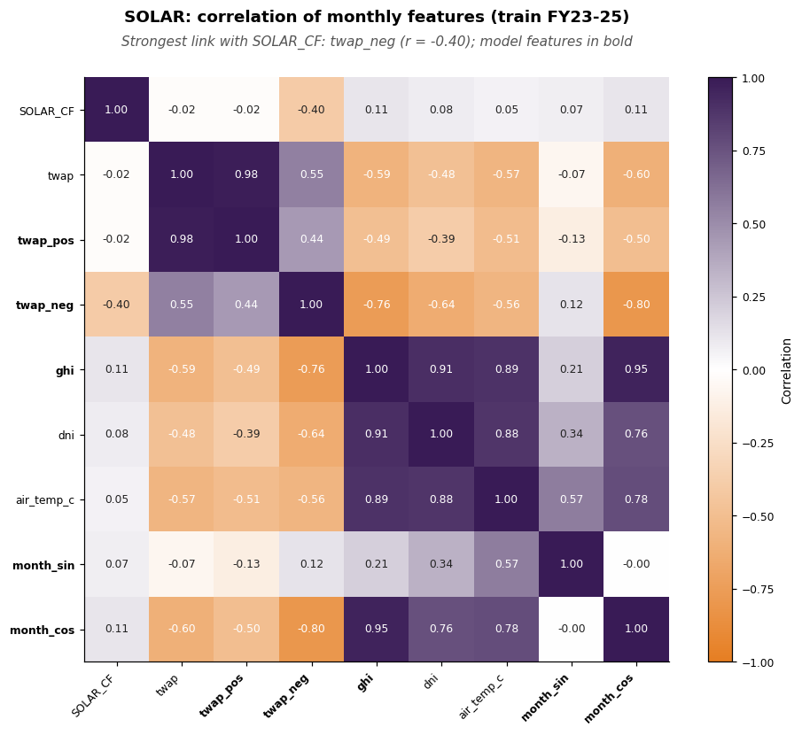

## Result for SOLAR CF - Overview

Training set: FY23-25, Test set: FY26. Model comparison using MAE

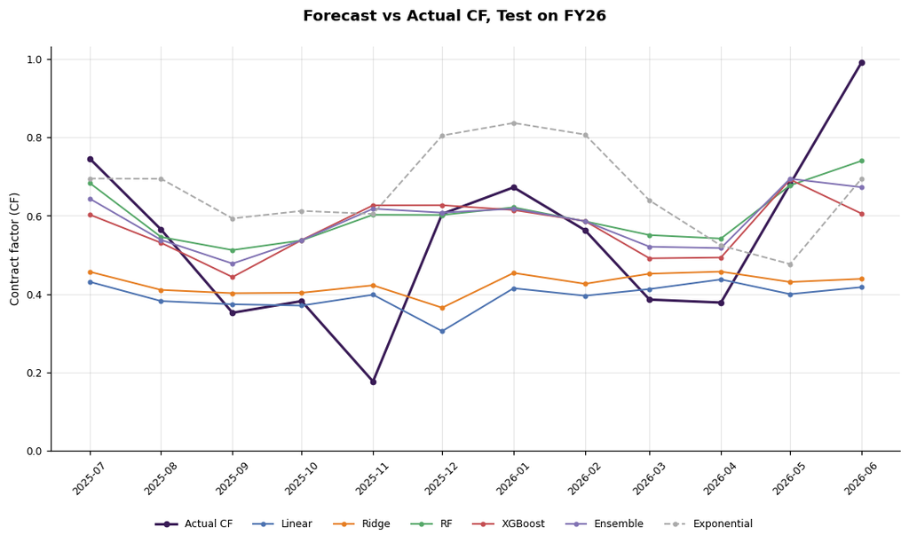

| Benchmark | MAE |
| --- | --- |
| Seasonal Naive | 0.152 |
| Exponential | 0.216 |
| Model | MAE |
| RF | **0.123** |
| Ensemble | 0.128 |
| XGBoost | 0.133 |
| Ridge | 0.192 |
| Linear | 0.201 |

- RF, Ensemble and XGBoost are the most accurate (MAE 0.123-0.133) and the only models that beat the Seasonal Naive baseline (0.152)
- The linear models do not beat Seasonal Naive (Ridge 0.192, Linear 0.201): they predict an almost flat CF and miss the seasonal swings
- All models miss the November trough (actual CF 0.18) and the June peak (0.99).

## Result for SOLAR CF - Best Tree vs Best Linear models

Feature importance

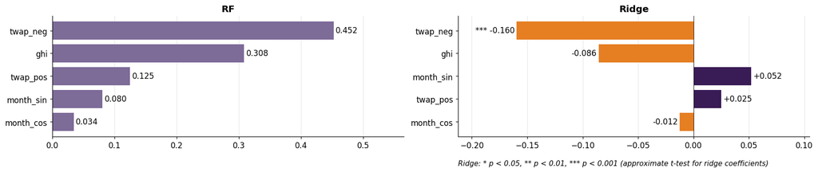

Test FY26

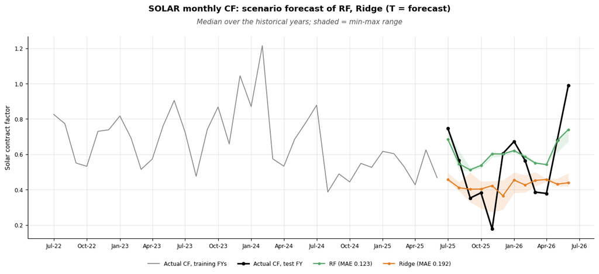

**Key takeaway:**

- Both models rely mostly on twap_neg: deeper negative prices give a higher CF. It is the only significant Ridge coefficient (p < 0.001)
- ghi is the second input of RF (share 0.31) but not significant in Ridge (p = 0.16): its effect on CF is not a straight line
- RF follows the seasonal cycle of actual CF; Ridge stays almost flat (0.37-0.46) and misses the swings
- Ridge’s band is wider than RF’s (Sep-Dec) but stays flat around 0.4: it only catches the low CF of Sep-Oct, while RF’s narrow band sits on the actual CF in Jul-Aug and Dec-Feb

## MAE by model (FY26 test)

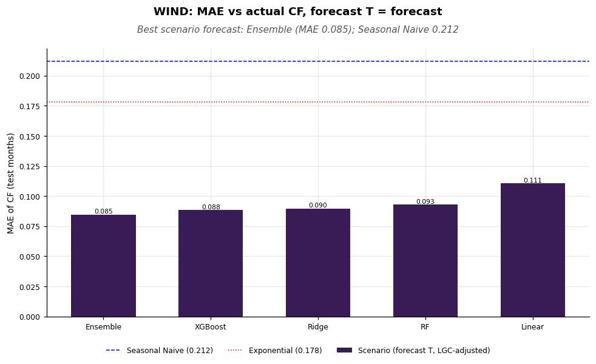

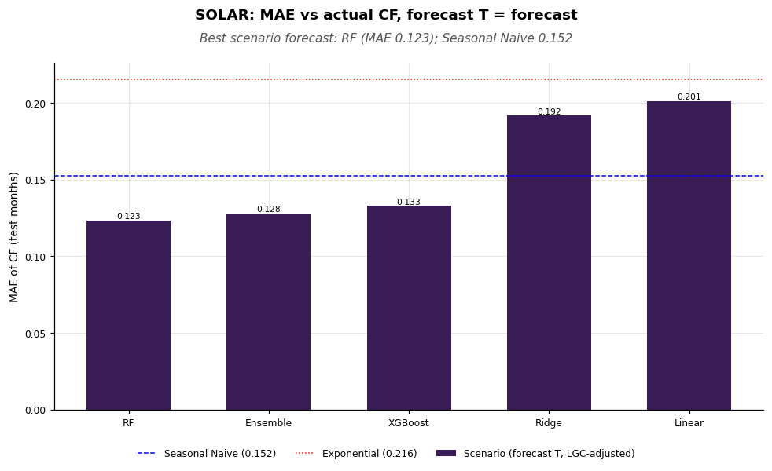

## Error metrics (FY26 test)

WIND

|  | n | MAE | RMSE | MAPE | R2 |
| --- | --- | --- | --- | --- | --- |
| Ensemble | 12 | 0.085 | 0.104 | 13.121 | 0.489 |
| XGBoost | 12 | 0.088 | 0.105 | 13.803 | 0.477 |
| Ridge | 12 | 0.090 | 0.121 | 14.883 | 0.305 |
| RF | 12 | 0.093 | 0.108 | 14.478 | 0.444 |
| Linear | 12 | 0.111 | 0.123 | 17.223 | 0.281 |
| Exponential | 12 | 0.178 | 0.233 | 31.317 | -1.564 |
| Seasonal Naive | 12 | 0.212 | 0.282 | 35.357 | -2.750 |

SOLAR

|  | n | MAE | RMSE | MAPE | R2 |
| --- | --- | --- | --- | --- | --- |
| RF | 12 | 0.123 | 0.172 | 38.493 | 0.331 |
| Ensemble | 12 | 0.128 | 0.180 | 38.539 | 0.268 |
| XGBoost | 12 | 0.133 | 0.190 | 38.391 | 0.182 |
| Seasonal Naive | 12 | 0.152 | 0.208 | 37.845 | 0.017 |
| Ridge | 12 | 0.192 | 0.237 | 37.609 | -0.267 |
| Linear | 12 | 0.201 | 0.255 | 37.330 | -0.466 |
| Exponential | 12 | 0.216 | 0.234 | 55.400 | -0.234 |

## Feature importance of every model - WIND

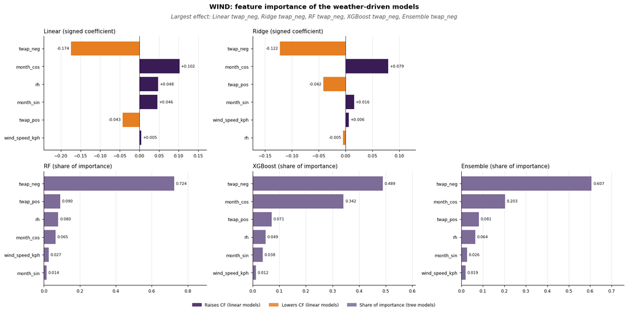

## Feature importance of every model - SOLAR

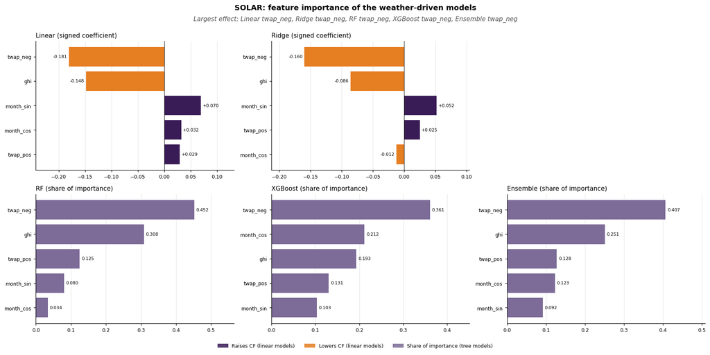

## Linear and Ridge fit: coefficients and checks

WIND

|  | Linear coef | Linear p | Ridge coef | Ridge p | VIF |
| --- | --- | --- | --- | --- | --- |
| wind_speed_kph | 0.005 | 0.871 | 0.006 | 0.753 | 1.541 |
| twap_neg | -0.172 | 0.000 | -0.122 | 0.000 | 2.921 |
| twap_pos | -0.042 | 0.124 | -0.042 | 0.038 | 1.411 |
| rh | 0.047 | 0.264 | -0.005 | 0.796 | 3.444 |
| month_sin | 0.045 | 0.146 | 0.016 | 0.400 | 1.837 |
| month_cos | 0.101 | 0.044 | 0.079 | 0.000 | 4.558 |

|  | Linear | Ridge |
| --- | --- | --- |
| R2 (training months) | 0.815 | 0.787 |
| Durbin-Watson (2 = no autocorrelation) | 2.383 | 2.044 |
| Breusch-Pagan p (> 0.05: constant variance) | 0.149 | 0.248 |
| Jarque-Bera p (> 0.05: normal residuals) | 0.584 | 0.767 |
| Ridge alpha (cross-validation) |  | 10 |
| Training months | 36 | 36 |

SOLAR

|  | Linear coef | Linear p | Ridge coef | Ridge p | VIF |
| --- | --- | --- | --- | --- | --- |
| ghi | -0.146 | 0.253 | -0.086 | 0.159 | 22.239 |
| twap_neg | -0.178 | 0.001 | -0.160 | 0.001 | 3.025 |
| twap_pos | 0.029 | 0.365 | 0.025 | 0.405 | 1.398 |
| month_sin | 0.069 | 0.090 | 0.052 | 0.086 | 2.170 |
| month_cos | 0.032 | 0.798 | -0.012 | 0.835 | 21.515 |

|  | Linear | Ridge |
| --- | --- | --- |
| R2 (training months) | 0.348 | 0.341 |
| Durbin-Watson (2 = no autocorrelation) | 1.940 | 1.887 |
| Breusch-Pagan p (> 0.05: constant variance) | 0.375 | 0.342 |
| Jarque-Bera p (> 0.05: normal residuals) | 0.705 | 0.660 |
| Ridge alpha (cross-validation) |  | 1 |
| Training months | 36 | 36 |

## Exponential baseline vs the best model (FY26 test)

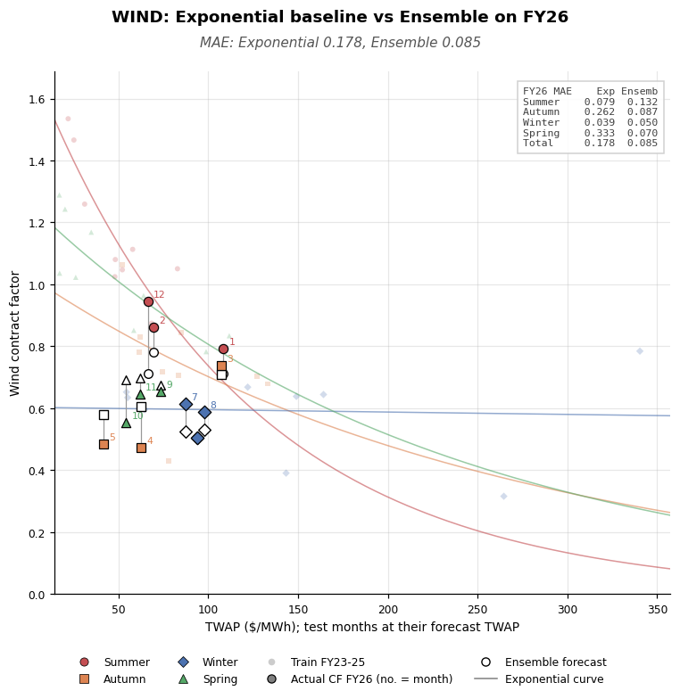

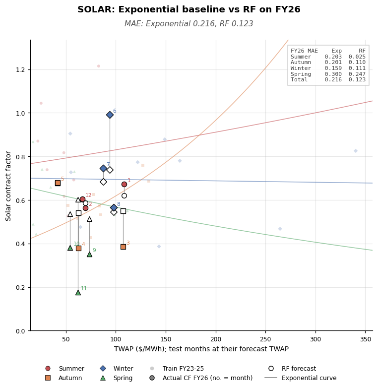

## FY27-29 forecast of every model - WIND

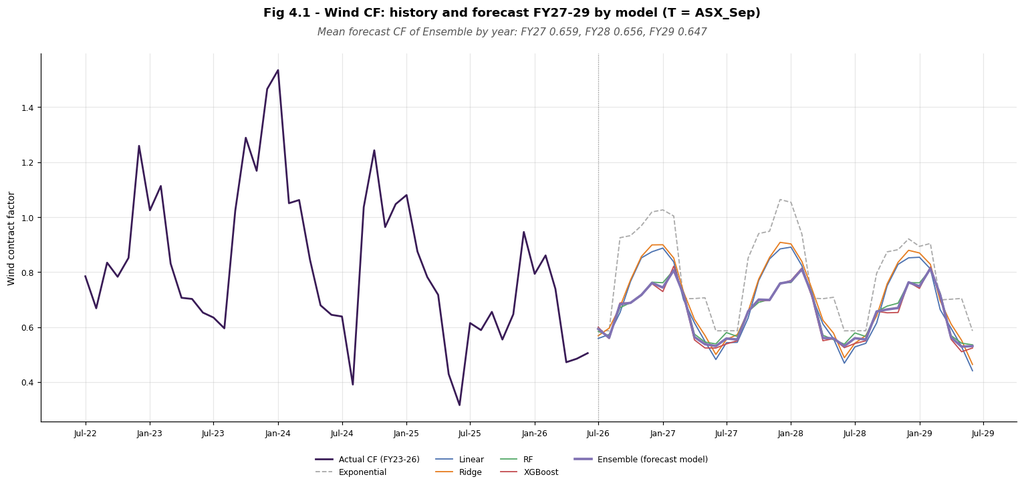

## FY27-29 forecast of every model - SOLAR

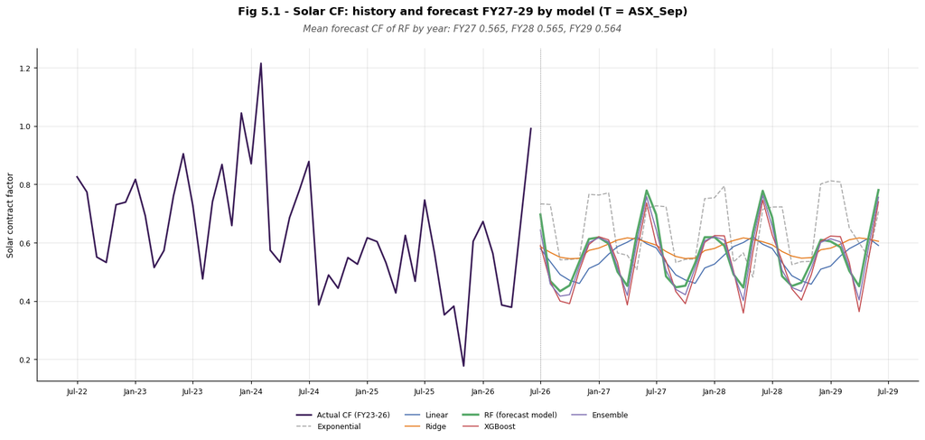